# Introduction & Univariate analysis

[figure not shown]

## Interesting resources:

- Python Basics
  - https://courses.edx.org/courses/course-v1:IBM+PY0101EN+3T2020/course/ Module 1, 2 & 3
- DataFrame Basics
  - https://campus.datacamp.com/courses/introduction-to-data-science-in-python/loading-data-in-pandas?ex=1
  - https://campus.datacamp.com/courses/pandas-foundations/data-ingestion-inspection?ex=1
  - https://www.coursera.org/learn/python-data-analysis?specialization=data-science-python#syllabus

## Intro Python, Pandas and DataFrames

```python
import pandas as pd
```

```python
import seaborn as sns
```

```python
iris = sns.load_dataset("iris")
```

```python
iris
```

|  | sepal_length | sepal_width | petal_length | petal_width | species |
| --- | --- | --- | --- | --- | --- |
| 0 | 5.1 | 3.5 | 1.4 | 0.2 | setosa |
| 1 | 4.9 | 3.0 | 1.4 | 0.2 | setosa |
| 2 | 4.7 | 3.2 | 1.3 | 0.2 | setosa |
| 3 | 4.6 | 3.1 | 1.5 | 0.2 | setosa |
| 4 | 5.0 | 3.6 | 1.4 | 0.2 | setosa |
| ... | ... | ... | ... | ... | ... |
| 145 | 6.7 | 3.0 | 5.2 | 2.3 | virginica |
| 146 | 6.3 | 2.5 | 5.0 | 1.9 | virginica |
| 147 | 6.5 | 3.0 | 5.2 | 2.0 | virginica |
| 148 | 6.2 | 3.4 | 5.4 | 2.3 | virginica |
| 149 | 5.9 | 3.0 | 5.1 | 1.8 | virginica |

150 rows × 5 columns

```python
type(iris)
```

```
pandas.core.frame.DataFrame
```

```python
iris.head()
```

|  | sepal_length | sepal_width | petal_length | petal_width | species |
| --- | --- | --- | --- | --- | --- |
| 0 | 5.1 | 3.5 | 1.4 | 0.2 | setosa |
| 1 | 4.9 | 3.0 | 1.4 | 0.2 | setosa |
| 2 | 4.7 | 3.2 | 1.3 | 0.2 | setosa |
| 3 | 4.6 | 3.1 | 1.5 | 0.2 | setosa |
| 4 | 5.0 | 3.6 | 1.4 | 0.2 | setosa |

[figure not shown]

```python
iris.columns
```

```
Index(['sepal_length', 'sepal_width', 'petal_length', 'petal_width',
       'species'],
      dtype='object')
```

```python
iris.dtypes
```

```
sepal_length    float64
sepal_width     float64
petal_length    float64
petal_width     float64
species          object
dtype: object
```

```python
print(iris.shape)
print(len(iris))
print(len(iris.columns))
```

```
(150, 5)
150
5
```

```python
iris['sepal_length']
```

```
0      5.1
1      4.9
2      4.7
3      4.6
4      5.0
      ...
145    6.7
146    6.3
147    6.5
148    6.2
149    5.9
Name: sepal_length, Length: 150, dtype: float64
```

```python
type(iris['sepal_length'])
```

```
pandas.core.series.Series
```

```python
iris[['sepal_length','sepal_width']]
```

|  | sepal_length | sepal_width |
| --- | --- | --- |
| 0 | 5.1 | 3.5 |
| 1 | 4.9 | 3.0 |
| 2 | 4.7 | 3.2 |
| 3 | 4.6 | 3.1 |
| 4 | 5.0 | 3.6 |
| ... | ... | ... |
| 145 | 6.7 | 3.0 |
| 146 | 6.3 | 2.5 |
| 147 | 6.5 | 3.0 |
| 148 | 6.2 | 3.4 |
| 149 | 5.9 | 3.0 |

150 rows × 2 columns

```python
columns = ['sepal_length','sepal_width']
iris[columns]
```

|  | sepal_length | sepal_width |
| --- | --- | --- |
| 0 | 5.1 | 3.5 |
| 1 | 4.9 | 3.0 |
| 2 | 4.7 | 3.2 |
| 3 | 4.6 | 3.1 |
| 4 | 5.0 | 3.6 |
| ... | ... | ... |
| 145 | 6.7 | 3.0 |
| 146 | 6.3 | 2.5 |
| 147 | 6.5 | 3.0 |
| 148 | 6.2 | 3.4 |
| 149 | 5.9 | 3.0 |

150 rows × 2 columns

```python
type(columns)
```

```
list
```

```python
iris.loc[0:4] # inclusive! 0:4 are treated as labels, not indices!
```

|  | sepal_length | sepal_width | petal_length | petal_width | species |
| --- | --- | --- | --- | --- | --- |
| 0 | 5.1 | 3.5 | 1.4 | 0.2 | setosa |
| 1 | 4.9 | 3.0 | 1.4 | 0.2 | setosa |
| 2 | 4.7 | 3.2 | 1.3 | 0.2 | setosa |
| 3 | 4.6 | 3.1 | 1.5 | 0.2 | setosa |
| 4 | 5.0 | 3.6 | 1.4 | 0.2 | setosa |

[Good explanation about pandas](https://medium.com/dunder-data/selecting-subsets-of-data-in-pandas-6fcd0170be9c)

```python
iris.loc[0:4, columns]
```

|  | sepal_length | sepal_width |
| --- | --- | --- |
| 0 | 5.1 | 3.5 |
| 1 | 4.9 | 3.0 |
| 2 | 4.7 | 3.2 |
| 3 | 4.6 | 3.1 |
| 4 | 5.0 | 3.6 |

```python
versicolorFilter = iris['species'] == 'versicolor'
iris[versicolorFilter].head()
```

|  | sepal_length | sepal_width | petal_length | petal_width | species |
| --- | --- | --- | --- | --- | --- |
| 50 | 7.0 | 3.2 | 4.7 | 1.4 | versicolor |
| 51 | 6.4 | 3.2 | 4.5 | 1.5 | versicolor |
| 52 | 6.9 | 3.1 | 4.9 | 1.5 | versicolor |
| 53 | 5.5 | 2.3 | 4.0 | 1.3 | versicolor |
| 54 | 6.5 | 2.8 | 4.6 | 1.5 | versicolor |

## Univariate analysis

Unvariate: Look at 1 column at a time.  
The type of univariate analysis that can be performed depends on the type of data the column has.

[figure not shown]

### Univariate analysis: Categorical data

Discrete values. Like enums.

```python
iris['species']
```

```
0         setosa
1         setosa
2         setosa
3         setosa
4         setosa
         ...
145    virginica
146    virginica
147    virginica
148    virginica
149    virginica
Name: species, Length: 150, dtype: object
```

```python
iris['species'].unique()
```

```
array(['setosa', 'versicolor', 'virginica'], dtype=object)
```

```python
iris['species'].value_counts()
```

```
setosa        50
versicolor    50
virginica     50
Name: species, dtype: int64
```

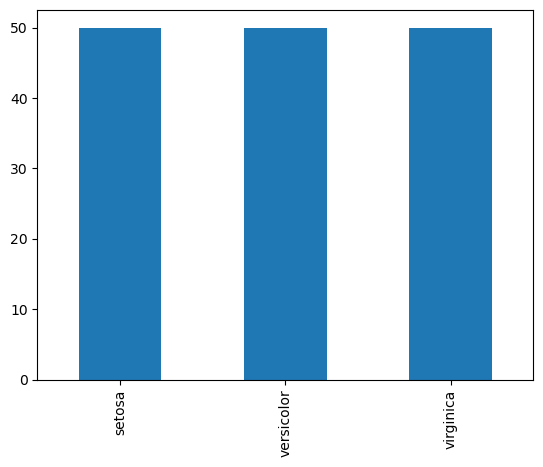

```python
iris['species'].value_counts().plot(kind='bar')
```

### Portfolio assignment 3

15 min: Perform a univariate analysis on all the categorical data of the penguins dataset. Commit the notebook to your portfolio when you're finished. Optional: Start working on portfolio assignment 4

```python
penguins = sns.load_dataset("penguins")
```

```python
penguins.head()
```

|  | species | island | bill_length_mm | bill_depth_mm | flipper_length_mm | body_mass_g | sex |
| --- | --- | --- | --- | --- | --- | --- | --- |
| 0 | Adelie | Torgersen | 39.1 | 18.7 | 181.0 | 3750.0 | Male |
| 1 | Adelie | Torgersen | 39.5 | 17.4 | 186.0 | 3800.0 | Female |
| 2 | Adelie | Torgersen | 40.3 | 18.0 | 195.0 | 3250.0 | Female |
| 3 | Adelie | Torgersen | NaN | NaN | NaN | NaN | NaN |
| 4 | Adelie | Torgersen | 36.7 | 19.3 | 193.0 | 3450.0 | Female |

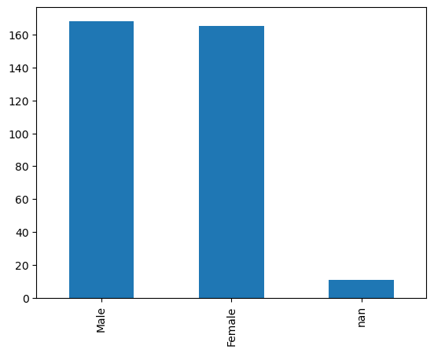

```python
penguins['sex'].value_counts(dropna=False).plot(kind='bar')
```

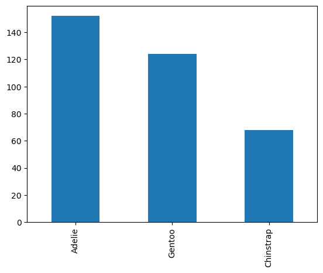

```python
penguins['species'].value_counts(dropna=False).plot(kind='bar')
```

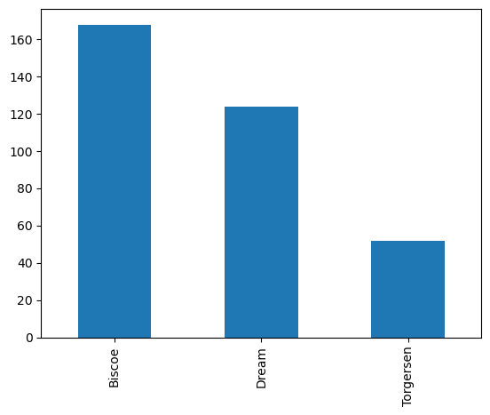

```python
penguins['island'].value_counts(dropna=False).plot(kind='bar')
```

```python
def create_contingency_table(dataset, column1, column2):
    return dataset.groupby([column1, column2]).size().unstack(column1, fill_value=0)
```

```python
flowersContingencyTable = create_contingency_table(penguins, 'species','island')
```

[figure not shown]

### Portfolio assignment 4

15 min: Look online for a datset that you personally find interesting to explore. It can be about any topic that you find interesting: sports, games, software development, etc. Commit the dataset to your portfolio. You will be analysing the dataset in future portfolio assignments.

Required characteristics of the dataset:

- Must be in a tabular format: Contains rows and columns
- Contains at least 100 rows
- Contains at least 2 columns with categorical data and at least 2 columns with numerical data
- Is less than 200 MB

[figure not shown]

```python
meteoriteLandings  = pd.read_csv('Meteorite_Landings.csv', sep=',')
```

```python
meteoriteLandings.head()
```

|  | name | id | nametype | recclass | mass (g) | fall | year | reclat | reclong | GeoLocation |
| --- | --- | --- | --- | --- | --- | --- | --- | --- | --- | --- |
| 0 | Aachen | 1 | Valid | L5 | 21.0 | Fell | 1880.0 | 50.77500 | 6.08333 | (50.775, 6.08333) |
| 1 | Aarhus | 2 | Valid | H6 | 720.0 | Fell | 1951.0 | 56.18333 | 10.23333 | (56.18333, 10.23333) |
| 2 | Abee | 6 | Valid | EH4 | 107000.0 | Fell | 1952.0 | 54.21667 | -113.00000 | (54.21667, -113.0) |
| 3 | Acapulco | 10 | Valid | Acapulcoite | 1914.0 | Fell | 1976.0 | 16.88333 | -99.90000 | (16.88333, -99.9) |
| 4 | Achiras | 370 | Valid | L6 | 780.0 | Fell | 1902.0 | -33.16667 | -64.95000 | (-33.16667, -64.95) |

```python
meteoriteLandings.describe()
```

|  | id | mass (g) | year | reclat | reclong |
| --- | --- | --- | --- | --- | --- |
| count | 45716.000000 | 4.558500e+04 | 45425.000000 | 38401.000000 | 38401.000000 |
| mean | 26889.735104 | 1.327808e+04 | 1991.828817 | -39.122580 | 61.074319 |
| std | 16860.683030 | 5.749889e+05 | 25.052766 | 46.378511 | 80.647298 |
| min | 1.000000 | 0.000000e+00 | 860.000000 | -87.366670 | -165.433330 |
| 25% | 12688.750000 | 7.200000e+00 | 1987.000000 | -76.714240 | 0.000000 |
| 50% | 24261.500000 | 3.260000e+01 | 1998.000000 | -71.500000 | 35.666670 |
| 75% | 40656.750000 | 2.026000e+02 | 2003.000000 | 0.000000 | 157.166670 |
| max | 57458.000000 | 6.000000e+07 | 2101.000000 | 81.166670 | 354.473330 |

### Univariate analysis: Numerical data

```python
column = 'sepal_length'
iris[column].min()
```

```
4.3
```

```python
iris[column].max()
```

```
7.9
```

```python
iris[column].mean()
```

```
5.843333333333335
```

[figure not shown]

```python
iris[column].median()
```

```
5.8
```

[figure not shown]

```python
example_column1 = pd.Series([1,2,3,4, 1000])
```

```python
print(example_column1.mean())
print(example_column1.median())
```

```
202.0
3.0
```

```python
iris[column].std()
```

```
0.8280661279778629
```

[figure not shown]

```python
example_column1.std()
```

```
446.0969625541066
```

```python
(((example_column1 - example_column1.mean())**2).sum() / ( len(example_column1)-1))**0.5
```

```
446.0969625541066
```

```python
example_column2 = pd.Series([1,1,1,1,1,1])
example_column3 = pd.Series([1,2,3,4,5,6])
example_column4 = pd.Series([1,2,3,4,5,100])
example_column5 = pd.Series([10,20,30,40,50,60])
```

```python
(example_column2.std(), example_column3.std(), example_column4.std(), example_column5.std())
```

```
(0.0, 1.8708286933869707, 39.62532860010963, 18.708286933869708)
```

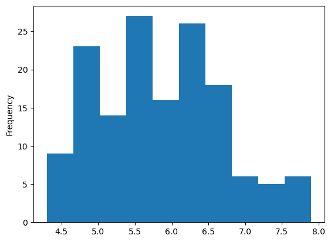

```python
iris[column].plot(kind='hist', bins = 10)
```

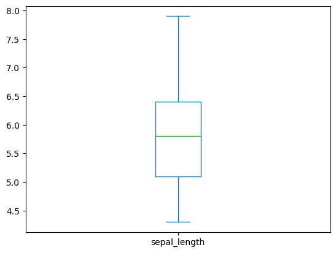

```python
iris[column].plot(kind='box')
```

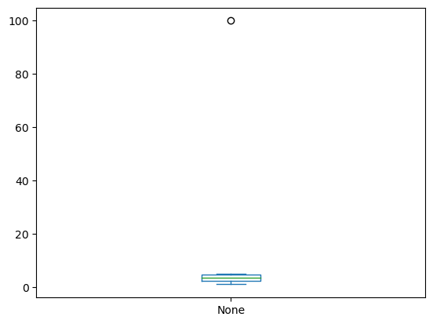

```python
example_column4.plot(kind='box')
```

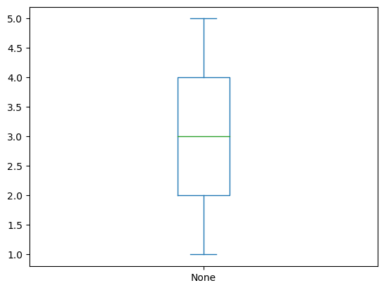

```python
# remove the outlier
example_column4[example_column4 < 10].plot(kind='box')
```

[figure not shown]

### Portfolio assignment 5

20 min:

- Download lifeExpectancyAtBirth.csv from Brightspace ([original source](https://www.kaggle.com/utkarshxy/who-worldhealth-statistics-2020-complete?select=lifeExpectancyAtBirth.csv)).
- Move the file to the same folder as the Notebook that you will be working in.
- Load the dataset in your Notebook with the following code: lifeExpectancy = pd.read_csv('lifeExpectancyAtBirth.csv', sep=',')
- Look at the dataset with the .head() function.
- Filter the dataframe: We only want the life expectancy data about 2019 and 'Both sexes'
- Use this dataframe to perform a univariate analysis on the life expectancy in 2019.
- Which five countries have the highest life expectancy? Which five the lowest?

Commit the notebook and dataset to your portfolio when you're finished.

[figure not shown]

```python
lifeExpectancy = pd.read_csv('lifeExpectancyAtBirth.csv', sep=',')
```

```python
lifeExpectancy.describe()
```

|  | Period | First Tooltip |
| --- | --- | --- |
| count | 2197.000000 | 2197.000000 |
| mean | 2010.958580 | 70.226331 |
| std | 7.366765 | 8.929307 |
| min | 1920.000000 | 27.970000 |
| 25% | 2000.000000 | 64.250000 |
| 50% | 2010.000000 | 71.830000 |
| 75% | 2015.000000 | 77.120000 |
| max | 2019.000000 | 86.940000 |

```python
lifeExpectancy.std()
```

```
Period           7.366765
First Tooltip    8.929307
dtype: float64
```

```python
lifeExpectancy.Period.std()
```

```
7.366765285335802
```

```python
lifeExpectancy['First Tooltip'].std()
```

```
8.929307485095029
```

```python
lifeExpectancy.head()
```

|  | Location | Period | Indicator | Dim1 | First Tooltip |
| --- | --- | --- | --- | --- | --- |
| 0 | Afghanistan | 2019 | Life expectancy at birth (years) | Both sexes | 63.21 |
| 1 | Afghanistan | 2019 | Life expectancy at birth (years) | Male | 63.29 |
| 2 | Afghanistan | 2019 | Life expectancy at birth (years) | Female | 63.16 |
| 3 | Afghanistan | 2015 | Life expectancy at birth (years) | Both sexes | 61.65 |
| 4 | Afghanistan | 2015 | Life expectancy at birth (years) | Male | 61.04 |

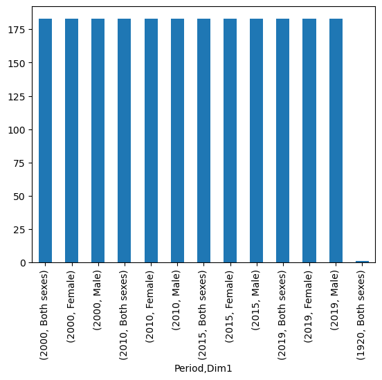

```python
lifeExpectancy[['Period', 'Dim1']].value_counts(dropna=False).plot(kind='bar')
```

```python
newDtSet = lifeExpectancy[(lifeExpectancy.Period == 2019) & (lifeExpectancy.Dim1 == "Both sexes")]
newDtSet[['Period', 'Dim1']].value_counts()
```

```
Period  Dim1
2019    Both sexes    183
dtype: int64
```

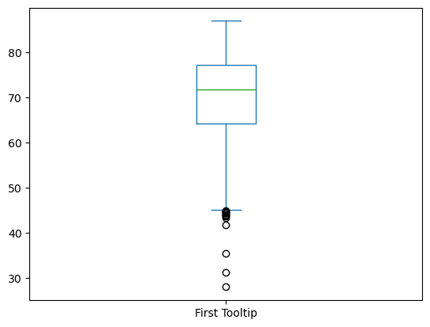

```python
life = lifeExpectancy[lifeExpectancy['First Tooltip'] > 10]
life['First Tooltip'].plot(kind='box')
```

```python
test = lifeExpectancy[['First Tooltip', 'Location']].sort_values('First Tooltip').tail()
test[['First Tooltip', 'Location']]
```

|  | First Tooltip | Location |
| --- | --- | --- |
| 1839 | 85.68 | Spain |
| 1005 | 85.77 | Japan |
| 1575 | 86.09 | Republic of Korea |
| 1002 | 86.41 | Japan |
| 999 | 86.94 | Japan |

```python
lifeExpectancy[['First Tooltip', 'Location']].sort_values('First Tooltip').head()
```

|  | First Tooltip | Location |
| --- | --- | --- |
| 860 | 27.97 | Haiti |
| 859 | 31.28 | Haiti |
| 861 | 35.37 | Haiti |
| 322 | 41.79 | Burundi |
| 383 | 43.24 | Central African Republic |

### Portfolio assignment 6

60 min: Perform a univariate analysis on at least 2 columns with categorical data and on at least 2 columns with numerical data in the dataset that you chose in portfolio assignment 4. Commit the Notebook to your portfolio when you're finished.

[figure not shown]

```python
meteoriteLandings.head()
```

|  | name | id | nametype | recclass | mass (g) | fall | year | reclat | reclong | GeoLocation |
| --- | --- | --- | --- | --- | --- | --- | --- | --- | --- | --- |
| 0 | Aachen | 1 | Valid | L5 | 21.0 | Fell | 1880.0 | 50.77500 | 6.08333 | (50.775, 6.08333) |
| 1 | Aarhus | 2 | Valid | H6 | 720.0 | Fell | 1951.0 | 56.18333 | 10.23333 | (56.18333, 10.23333) |
| 2 | Abee | 6 | Valid | EH4 | 107000.0 | Fell | 1952.0 | 54.21667 | -113.00000 | (54.21667, -113.0) |
| 3 | Acapulco | 10 | Valid | Acapulcoite | 1914.0 | Fell | 1976.0 | 16.88333 | -99.90000 | (16.88333, -99.9) |
| 4 | Achiras | 370 | Valid | L6 | 780.0 | Fell | 1902.0 | -33.16667 | -64.95000 | (-33.16667, -64.95) |

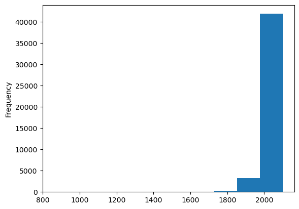

```python
meteoriteLandings.year.plot(kind='hist', bins = 10)
```

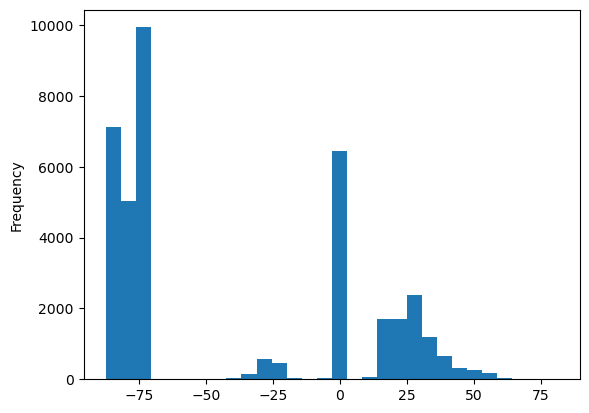

```python
meteoriteLandings.reclat.plot(kind='hist', bins=30)
```

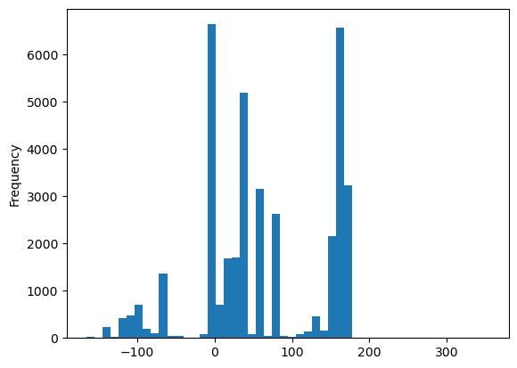

```python
meteoriteLandings.reclong.plot(kind='hist', bins=50)
```

```python
meteoriteLandings['mass (g)'].dropna().sort_values().head()
```

```
31063    0.0
31062    0.0
31075    0.0
12640    0.0
31064    0.0
Name: mass (g), dtype: float64
```

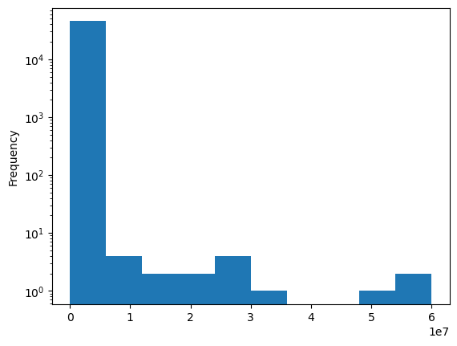

```python
mass = pd.Series(meteoriteLandings['mass (g)'])
mass.plot(kind='hist', logy=True)
```

```python
import matplotlib.pyplot as plt
import numpy as np
```

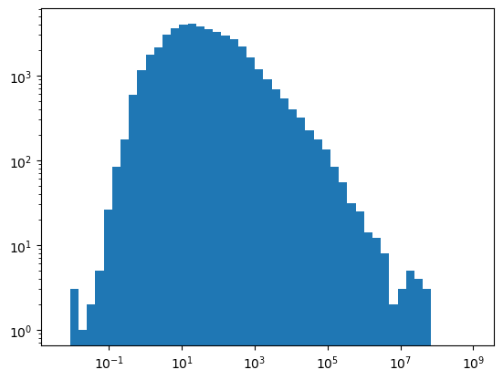

```python
plt.hist(mass, bins=np.logspace(np.log10(0.005),9.0, 50))
plt.xscale('log')
plt.yscale('log')
```

```python
meteoriteLandings.fall.describe()
```

```
count     45716
unique        2
top       Found
freq      44609
Name: fall, dtype: object
```

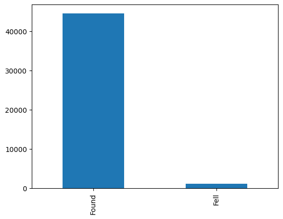

```python
meteoriteLandings.fall.value_counts().plot(kind='bar')
```

```python
meteoriteLandings.nametype.describe()
```

```
count     45716
unique        2
top       Valid
freq      45641
Name: nametype, dtype: object
```

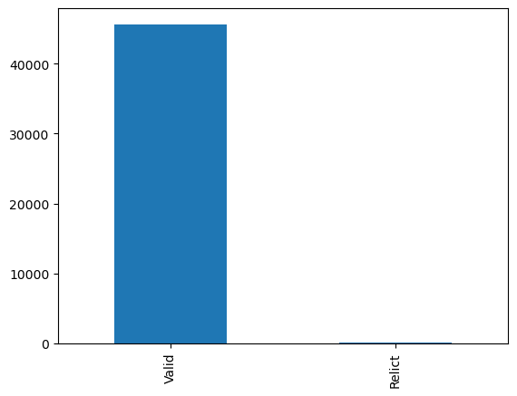

```python
meteoriteLandings.nametype.value_counts().plot(kind='bar')
```